# A Closer Look at NFL Scoring

Isaac Freeman

12/5/2018

# Intro

Since my main interest was the total number of points scored in each game, I needed to create a new variable for this, since it didn’t exist in the original table, so I added together the home score and the away score and called this variable “totalpoints”.

I was working with a huge dataset, so since most of my analysis is based on total points, I filtered out games without an over/under or totalpoints.

My dataset was still quite massive and messy to work with, so I chose to just look at the last 5 seasons, and selected only seasons 2013 and later.

# How Good Are We At Predicting Total Points Scored?

I was curious how accurate the over/under predictions actually are, so I plotted the over/unders for each game against the total number of points that were scored in that game. I also separated the graphs between playoff and regular season games to see if there was a difference in the correlation there.

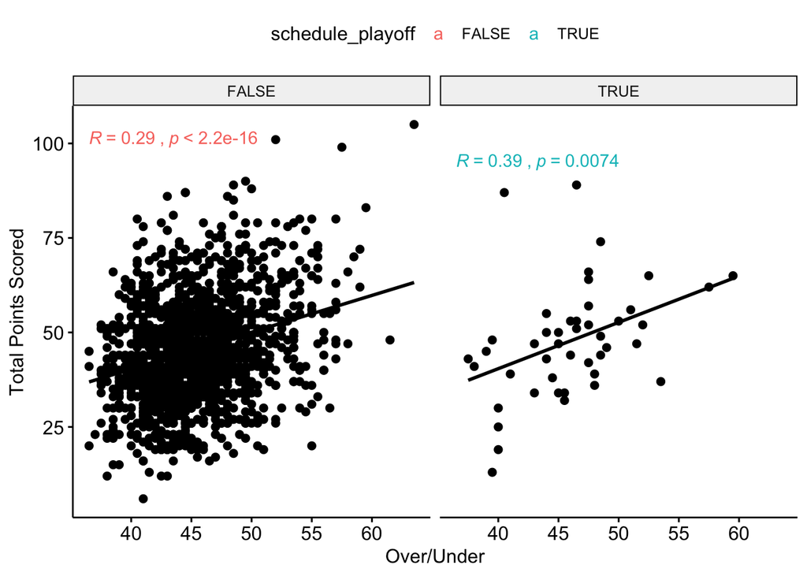

```r
#Test Correlation Between Over/Under and Total Points Scored
ggscatter(NFLDataTable, x = "over_under_line", y = "totalpoints",
          add = "reg.line", conf.int = FALSE,
          cor.coef = TRUE, cor.method = "pearson",
          xlab = "Over/Under", ylab = "Total Points Scored") +
            aes(color = schedule_playoff) + facet_wrap(~schedule_playoff)
```

# How Much of a Factor is The Weather?

I also wanted to check for a correlation between temperature and total points scored. I figured that there would be a positive correlation, since it becomes harder to throw and catch the ball as it gets colder, but I didn’t expect to see a very strong correlation.

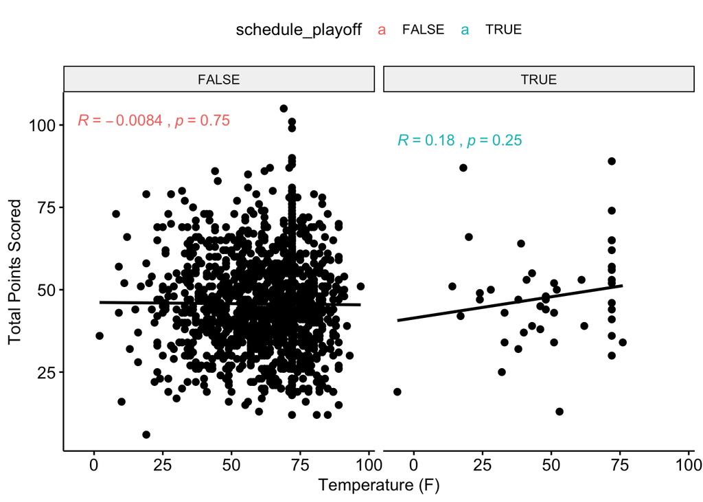

```r
#Test Correlation Between Temperature and Total Points Scored
ggscatter(NFLDataTable, x = "weather_temperature", y = "totalpoints",
          add = "reg.line", conf.int = FALSE,
          cor.coef = TRUE, cor.method = "pearson",
          xlab = "Temperature (F)", ylab = "Total Points Scored") +
            aes(color = schedule_playoff) + facet_wrap(~schedule_playoff)
```

I was very shocked to find that there was actually a slight negative correlation between the variables during the regular season (although it was so close to 0 that it was essentially negligent). In the playoffs, however, there was a low positive correlation there as shown in the graphs above.

Since I didn’t find much of a correlation between points and temperature, I wondered if maybe it was the wind speed that had more of an effect on scores. To test this, I only compared games that had wind speeds higher than 0 mph, because I wanted to see if there was a correlation, and the high proportion of games in domes would probably skew my numbers.

```r
#Filter out games with wind speeds of 0
NFLDataTableWindy <-
  NFLDataTable %>%
  filter(weather_wind_mph > 0)
```

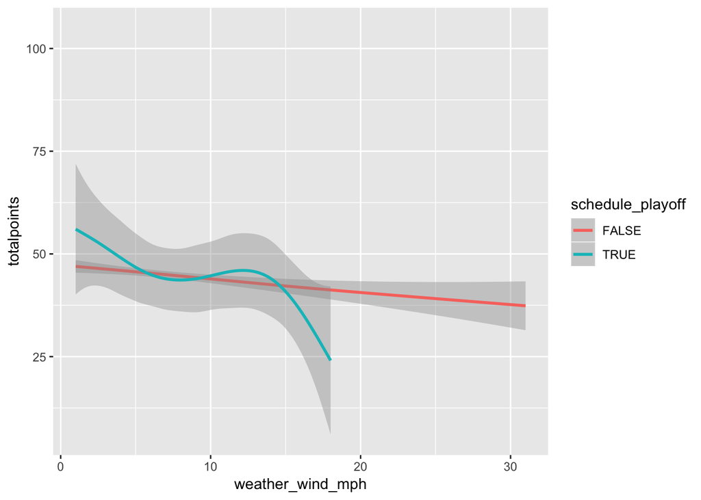

```r
#Graphing Points Vs Wind Speeds
NFLDataTableWindy %>%
  ggplot(aes(x = weather_wind_mph, y = totalpoints, color = schedule_playoff)) + stat_smooth() + geom_point(alpha = 0)
```

We can see a more clear negative trend here, especially in the playoff games, that higher wind speeds result in lower point totals. But again, it is very subtle. This lack of a strong correlation has been very eye-opening to me considering the weekly advice from fantasy football “experts” that says to avoid playing players in cold or windy conditions.

I was curious what the average number of points scored per NFL game has been over the past 5 years. Judging by my previous graphs, I figured it would be somewhere between 40 and 50.

```r
mean(as.vector(NFLDataTable$totalpoints))
```

```
## [1] 45.74417
```

I calculated the exact value to be 45.74417, right around what I was expecting.

# How Many Points Do Teams Score?

I was also curious what the distribution of number of points scored per game looked like, although I guessed it would be approximately normal.

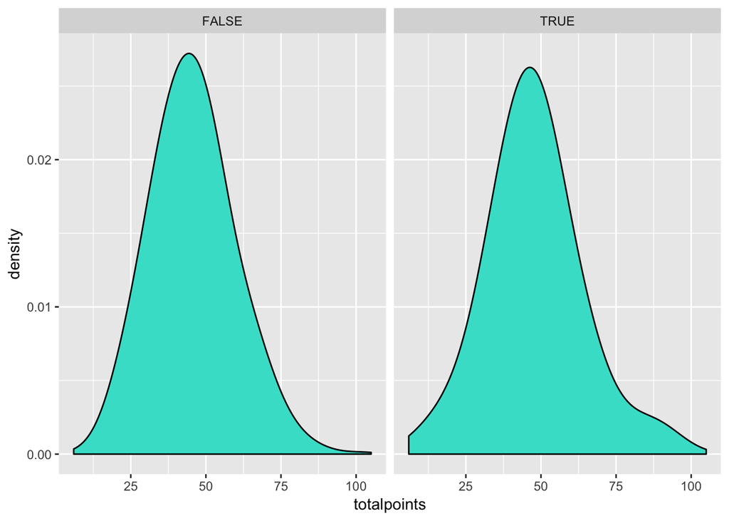

```r
#Plotting Point Distribution
NFLDataTable %>%
  ggplot(aes(x = totalpoints)) +
  geom_density(fill = "turquoise", adjust = 2) +
  facet_wrap(~schedule_playoff)
```

# A New Scoring Model

I decided to come up with my own predictive model for total points scored, using over/under, temperature, and wind as predictors (I only used games with wind speed of 1 mph or more).

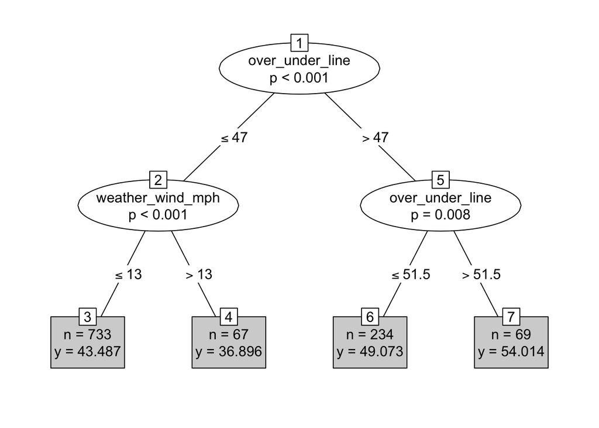

```r
#Creating my predictive model
MyModel <-
  party::ctree(totalpoints ~ over_under_line + weather_temperature + weather_wind_mph, data = NFLDataTableWindy)
plot(MyModel, type = "simple")
```

This model ended up not even taking the temperature into account at all, which is not very surprising considering the fact that the correlation that I found earlier was so insignificant. Also unsurprisingly, the over/under line was the most accurate predictor for total points, but the decision tree does show that wind is more of a factor in lower scoring games, less than 47 points specifically.

# Conlcusion

Through this investigation, I have learned that over/unders are actually quite accurate, and that weather doesn’t play nearly as much of a role in the number of points scored in a game as people think.